# 1. Cartograma

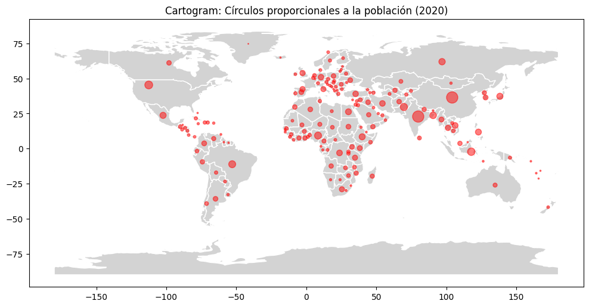

Esta visualización representa la distribución global de la población mundial en 2020 mediante círculos proporcionales superpuestos sobre un mapa base. Cada círculo rojo varía en tamaño según la población de la región representada, permitiendo una comparación visual inmediata entre diferentes zonas geográficas

Aspectos que resalta:

Hay contraste entre regiones densamente pobladas y áreas grandes con escasa población como partes de Australia, Siberia y centro de Sudamérica

El cartograma busca comunicar visualmente las disparidades poblacionales globales y nos permite identificar inmediatamente dónde se concentra la población mundial sin perder el contexto geográfico y a diferencia de un mapa coroplético tradicional, esta técnica evita sobrevalorar visualmente países grandes con poca población.

# 2. Flow Map (Mapa de Flujo) - Utilizando KeplerGl y datos UK de movimientos de personas

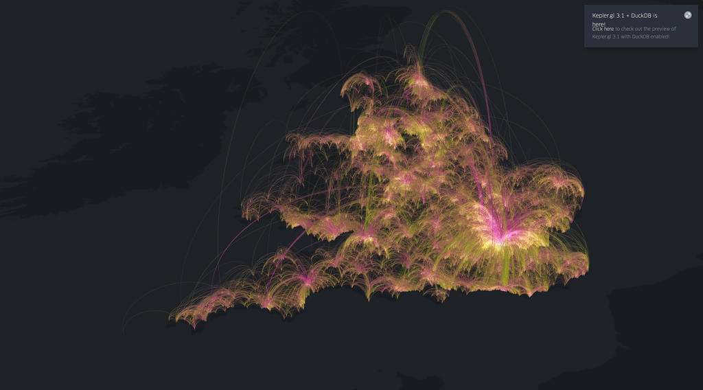

Esta visualización muestra patrones de desplazamiento entre diferentes localidades de Inglaterra y Gales mediante arcos tridimensionales. Cada arco representa flujos de personas que se desplazan entre un origen y un destino, donde la intensidad del movimiento se refleja en el grosor y el color de las líneas.

Aspectos que resalta:

- Los principales corredores de movilidad en Inglaterra y Gales
- La centralidad de ciertos núcleos urbanos como atractores de desplazamientos
- La interconexión entre diferentes regiones del país

Patrones radiales desde/hacia grandes ciudades (presumiblemente Londres y otras áreas metropolitanas)

El mapa de flujo busca revelar patrones de movilidad humana que normalmente permanecen invisibles, mostrando cómo las personas se desplazan habitualmente entre diferentes áreas geográficas. Esta visualización permite comprender mejor la estructura funcional del territorio, identificando áreas que actúan como origen o destino de desplazamientos frecuentes.

# 3. Bullet Graph

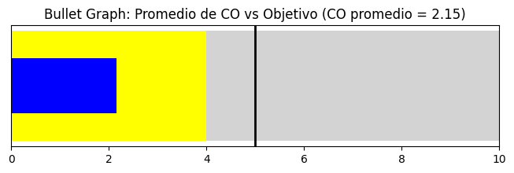

Esta visualización muestra el promedio de emisiones de CO (monóxido de carbono) en comparación con un valor objetivo. El valor actual (2.15) se representa mediante una barra azul, mientras que el objetivo se marca con una línea vertical. Los rangos de fondo en diferentes colores (amarillo y gris) representan diferentes umbrales de evaluación cualitativa.

Aspectos que resalta:

- La relación entre el valor actual de CO (2.15) y el objetivo establecido
- La categorización del rendimiento mediante rangos cromáticos que indican diferentes niveles de evaluación
- La brecha existente entre la situación actual y la meta deseada

El formato de gráfico de bala es particularmente efectivo para mostrar una única métrica de rendimiento en contexto y a diferencia de un simple gráfico de barras, incorpora elementos adicionales (rangos cualitativos, marcadores de objetivos) que proporcionan contexto interpretativo.

```python
#@title Convert ipynb to HTML in Colab
# Upload ipynb
from google.colab import files
f = files.upload()

# Convert ipynb to html
import subprocess
file0 = list(f.keys())[0]
_ = subprocess.run(["pip", "install", "nbconvert"])
_ = subprocess.run(["jupyter", "nbconvert", file0, "--to", "html"])

# download the html
files.download(file0[:-5]+"html")
```

Upload widget is only available when the cell has been executed in the current browser session. Please rerun this cell to enable.

```
Saving PEC_2_Visualizacion_de_datos (1).ipynb to PEC_2_Visualizacion_de_datos (1).ipynb
```